# (Prosper Loan)

## by (Amira Fathy )

## Investigation Overview

in this investigation, I wanted to look at the loan amount and relationship between (term , years,occupation , risk tatio )

## Dataset Overview

The dataset contains 113,937 loans with 81 features .

and this is the variable Definitions:

https://docs.google.com/spreadsheets/d/1gDyi_L4UvIrLTEC6Wri5nbaMmkGmLQBk-Yx3z0XDEtI/edit#gid=0

## 1.(The common Term )

we can see the most common of the term here is 36 months it has 77%

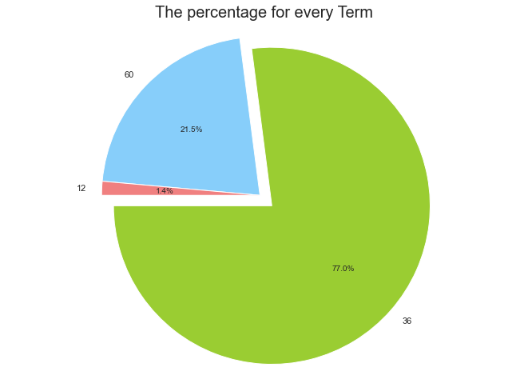

```python
# use pie to see the percentage for every Term
colors = ['yellowgreen', 'lightskyblue', 'lightcoral']
explode = (0.1, 0, 0)
plt.figure(figsize=[ 11.69, 8.27])
plt.pie(df_copy.Term.value_counts(),labels=df_copy.Term.value_counts().index,
        colors=colors,autopct='%1.1f%%',startangle=180,explode=explode)


plt.axis('equal')

plt.title('The percentage for every Term ',fontsize=20)
```

## 2.(LoanOriginalAmount vs risk ratio in each term )

1- term 60 months had the biggest loan amount and not have hr risk

2- 36 months had an average loan amount and have hr risk

3- 12 months had a less loan amount and not have hr risk

The term before 7-2009 was 36 months only

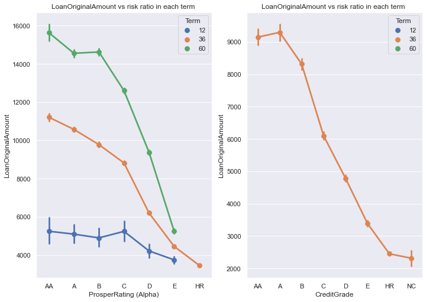

```python
#LoanOriginalAmount vs risk ratio in each term
plt.figure(figsize=[ 11.69, 8.27])
plt.subplot(1,2,1)
rate_order2 = ['AA','A','B','C','D','E','HR']
sb.pointplot(data = df_copy, x = 'ProsperRating (Alpha)', y = 'LoanOriginalAmount', hue = 'Term',order=rate_order2)
plt.title('LoanOriginalAmount vs risk ratio in each term ')

plt.subplot(1,2,2)
rate_order = ['AA','A','B','C','D','E','HR','NC']

sb.pointplot(data = df_copy, x = 'CreditGrade', y = 'LoanOriginalAmount', hue = 'Term',order=rate_order)
plt.title('LoanOriginalAmount vs risk ratio in each term ')
```

## 3.(the distribution of the count of loan from 2005 to 2014)

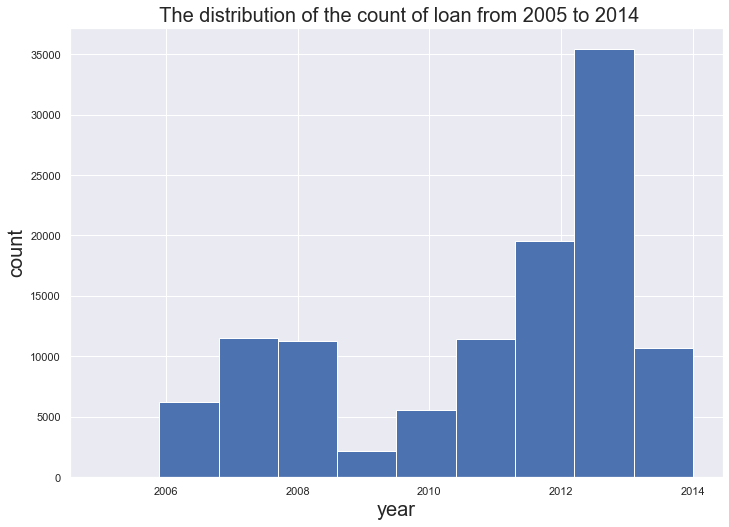

```python
# histogram for years it shows the distribution of the count of loan from 2005 to 2014
plt.figure(figsize=[ 11.69, 8.27])
plt.hist(data=df_copy,x='year')
plt.xlabel('year',fontsize=20)
plt.ylabel('count',fontsize=20)
plt.title(' The distribution of the count of loan from 2005 to 2014',fontsize=20)
```

## 4. ( risk ratio )

we can see the rating was **c** before 7-2009 and still **c** after 7-2009

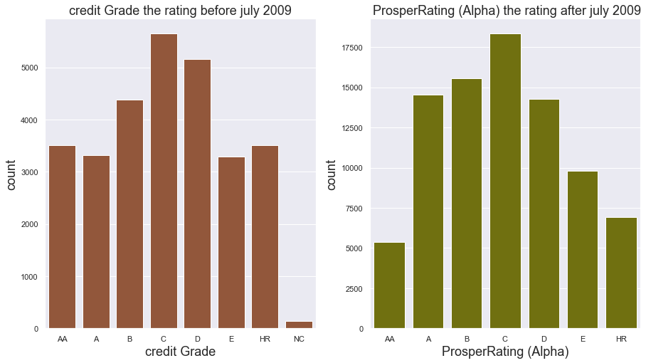

```python
# Credit Grade the risk raito before 7-2009
rate_order = ['AA','A','B','C','D','E','HR','NC']
ordered_var = pd.api.types.CategoricalDtype(ordered = True,categories = rate_order)
df1['CreditGrade']=df1.CreditGrade.astype(ordered_var)
plt.figure(figsize=(15,8))
plt.subplot(1,2,1)
sb.countplot(data=df1,x='CreditGrade' ,color='sienna')
plt.xlabel('credit Grade',fontsize=18)
plt.ylabel('count',fontsize=18)
plt.title('credit Grade the rating before july 2009',fontsize=18)
#  ProsperRating (Alpha) the risk raito after 7-2009
plt.subplot(1,2,2)
rate_order2 = ['AA','A','B','C','D','E','HR']
ordered_var2 = pd.api.types.CategoricalDtype(ordered = True,categories = rate_order2)
df2['ProsperRating (Alpha)']=df2['ProsperRating (Alpha)'].astype(ordered_var2)

sb.countplot(data=df2,x='ProsperRating (Alpha)',color='olive')
plt.xlabel('ProsperRating (Alpha)',fontsize=18)
plt.ylabel('count',fontsize=18)
plt.title(' ProsperRating (Alpha) the rating after july 2009',fontsize=18)
```

## 5.(Listing Category)

Debt consolidation was the common reason to did a loan

but we have a few reasons here why???

the answer will be in the next slid >>

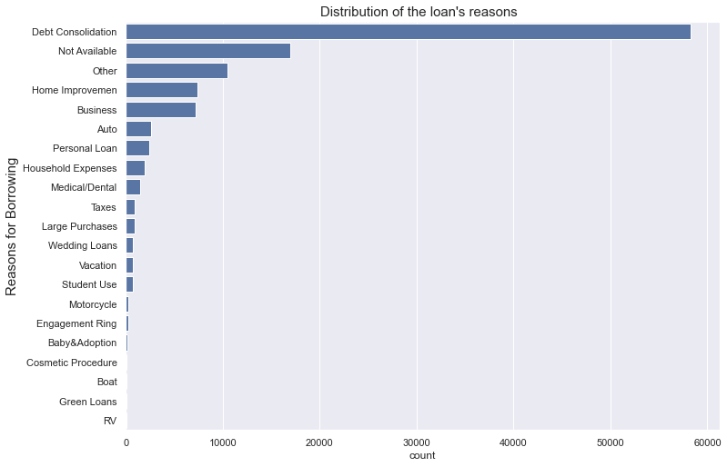

```python
#   in the data  there are 20 reason for loan  from 0 to 20
reasons = {0:"Not Available", 1: "Debt Consolidation", 2: "Home Improvemen", 3: "Business", 4: "Personal Loan",
5:"Student Use", 6: "Auto", 7: "Other",  8:"Baby&Adoption", 9:"Boat", 10:"Cosmetic Procedure", 11:"Engagement Ring",
12: "Green Loans", 13:"Household Expenses", 14:"Large Purchases",
15:"Medical/Dental", 16:"Motorcycle", 17:"RV", 18:"Taxes", 19:"Vacation", 20:"Wedding Loans"}

df_copy['ListingCategory']=df_copy['ListingCategory (numeric)'].map(reasons)

# Plotting the univariate graph of the reasons of haveing a loan
plt.figure(figsize=[ 11.69, 8.27])
sb.countplot(data=df_copy, y='ListingCategory', color=sb.color_palette()[0],
             order= df_copy.ListingCategory.value_counts().index)
plt.ylabel('Reasons for Borrowing',fontsize=15)
plt.title('Distribution of the loan\'s reasons  ',fontsize=15)
```

we asked about why of some of the reasons had fewer counts

because >> the some of reasons loan was beginning at last 4 years (2011-1014) like (Motorcycle ,Vacation ,Household Expenses, Medical/Dental,Engagement Ring ,Taxes, Baby&Adoption, Green Loans ,Large Purchases )

and the some of reasons loan was beginning at last 3 years (2012-2014) like (Boat, RV)

so how these reasons effect on the loan amout ??? we know it in the next slide >>>

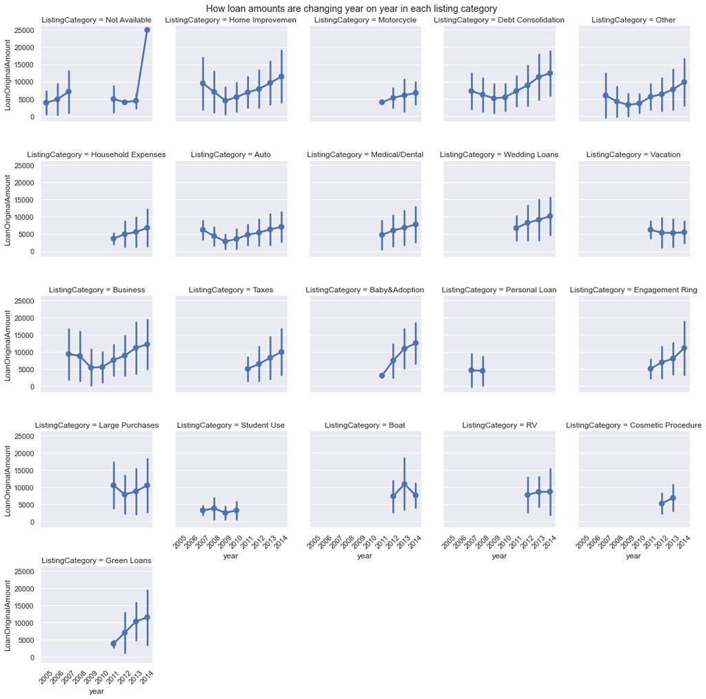

```python
sb.set()
year_order = np.sort(df_copy.year.unique())
plt.figure(figsize=[ 11.69, 8.27])
g=sb.FacetGrid(data=df_copy, col='ListingCategory', col_wrap=5)
g.map(sb.pointplot, 'year','LoanOriginalAmount', ci='sd', order=year_order)
g.set_xticklabels(rotation=45)
g.fig.suptitle('How loan amounts are changing year on year in each listing category ')
plt.tight_layout()
g.fig.subplots_adjust(top=0.95);
```

The new reasons previous was made the amount of the loan is bigger than before

we can see the loans from 2012 -2014 is bigger than before

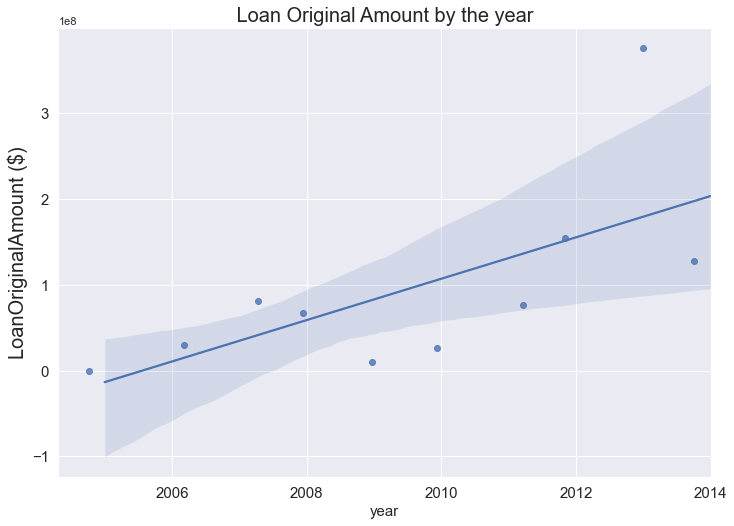

```python
# loan original amount by the year
plt.figure(figsize=[ 11.69, 8.27])
year_loan=df_copy.groupby('year').LoanOriginalAmount.sum()
sb.regplot(data=df_copy,x=year_loan.index,y=year_loan,x_jitter=0.3)
plt.title(' Loan Original Amount by the year ',fontsize=20)
plt.xlabel('year',fontsize=15)
plt.ylabel('LoanOriginalAmount ($)',fontsize=20)
plt.xticks(fontsize=15)
plt.yticks(fontsize=15)
```

## 6- income monthly vs occupation

doctor occupation that is the most average income monthly , and students are the least income

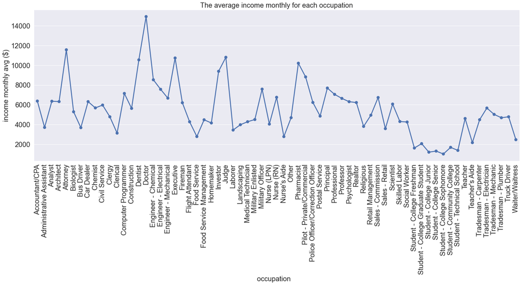

```python
#average income  monthly
plt.figure(figsize = [25, 8])
sb.pointplot(data=df_copy,x=df_copy.groupby('Occupation').StatedMonthlyIncome.mean().index
             ,y=df_copy.groupby('Occupation').StatedMonthlyIncome.mean())
plt.xticks(rotation=90,fontsize=20)
plt.yticks(rotation=0,fontsize=20)
plt.ylabel('income monthly avg ($)',fontsize=20)
plt.title('The average income monthly for each occupation',fontsize=20)
plt.xlabel('occupation   ',fontsize=20)
```